# How did the pandemic change the movement of people around the world?

Ranjini Grove

Department of Statistics

## Introduction

The learning goals for today are:

1. Get acquainted with the programming toolkit.
2. Visualize the initial effect of the pandemic on mobility patterns.
3. Make comparisons across countries.

## Getting Started

Please introduce yourselves to each other.You have about 20 minutes to work on this.

## The Google Mobility Dataset

The data set is too large to show in its entirety, however, a quick look at the first several rows gives us a good idea:

| country_region | date | places_category | percent_change_from_baseline |
| --- | --- | --- | --- |
| United Arab Emirates | 2020-02-15 | retail_and_recreation | 0 |
| United Arab Emirates | 2020-02-15 | grocery_and_pharmacy | 4 |
| United Arab Emirates | 2020-02-15 | parks | 5 |
| United Arab Emirates | 2020-02-15 | transit_stations | 0 |
| United Arab Emirates | 2020-02-15 | workplaces | 2 |
| United Arab Emirates | 2020-02-15 | residential | 1 |

A description of the information in a dataset is typically referred to as a **codebook** and is shown below.

| Name | Description |
| --- | --- |
| `country_region` | Name of country |
| `date` | The date that the measurement was taken. |
| `places_category` | Type of location (residence, grocery, retail, park, work) |
| `percent change from baseline` | Change in number of visitors from baseline (for residential locations only, we use duration of visit). |

Baseline days represent a normal value for that day of the week, given as the average value over a five‑week period from January 3rd to February 6th 2020. Measuring change relative to a normal value for that day of the week is helpful because people obviously often have different routines on weekends versus weekdays.

## Visualizing the Data

The following lineplot shows changes in mobility patterns in Italy, one of the first countries in the western world to be hit by the coronavirus.

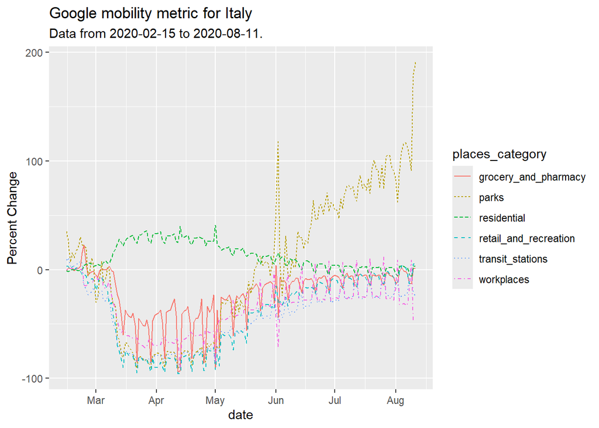

#### Discuss

1. Can you spot the start of COVID lockdowns?
2. Why the spike in early June in visits to the parks?
3. Do you see the weekend effect in the trend lines?

## Comparing Countries

Now let’s compare Italy to the United States. What trends seem similar across countries? What seems different?

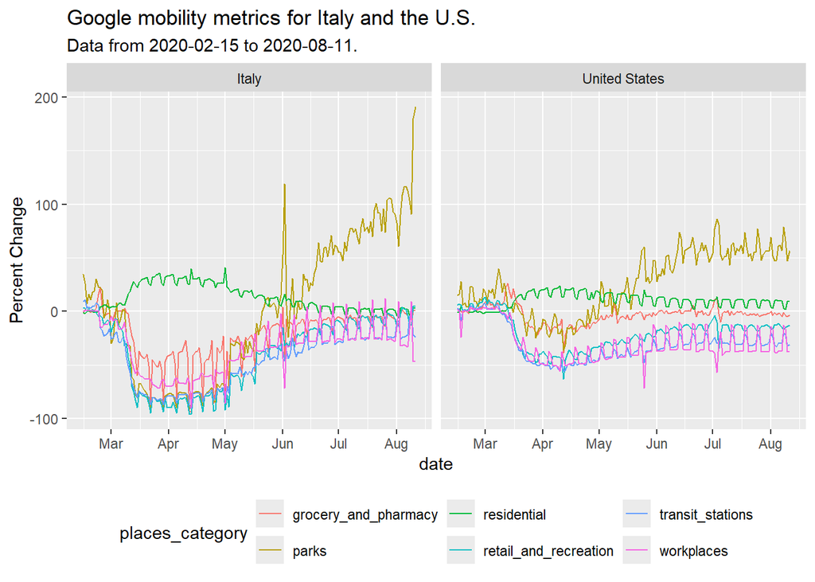

## Your turn!

Which countries are you most curious about? Pick two countries you wish to compare, but first check that the country is in the dataset by using the interactive table in the appendix. Then open the file `covidmobility.Rmd` on JupyterHub and take a look at the code to see if you can spot where the country names are specified. Change them to the two you are interested in. Knit the document and voila!

## Appendix

A list of countries in the `google_mobility_data` data frame is provided below.

| country_region |
| --- |
| Afghanistan |
| Angola |
| Antigua and Barbuda |
| Argentina |
| Aruba |
| Australia |
| Austria |
| India |
| Indonesia |
| Iraq |

[output cut: 18 more lines]

## Acknowledgements

This activity was developed by Ranjini Grove for UW Stat 311. Thanks go to Mine Çetinkaya-Rundel for her inspiring workshops on teaching introductory statistics and data science, and to Vincent Carey for his help with procuring the data and with the shiny App.